# Contents

1. Imports
2. Preprocessing
1. Loading Data
2. Extracting labels and images
3. Visualizing Data
4. Preparing the Dataset
3. ML Models
1. Making Some Functions
2. The Base Model
3. SVC
4. KNN
5. Decision Tree Classifier
6. Random Forest Classifier
7. XGBoost
8. Compare Models

# Imports

```python
import pandas as pd
import matplotlib.pyplot as plt
from sklearn.metrics import (
    accuracy_score,
    confusion_matrix,
    classification_report,
    ConfusionMatrixDisplay,
    precision_score,
)
from sklearn.model_selection import train_test_split
from sklearn.linear_model import LogisticRegression
from sklearn.svm import SVC
from sklearn.neighbors import KNeighborsClassifier
from sklearn.tree import DecisionTreeClassifier
from sklearn.ensemble import (
    RandomForestClassifier,
)
from xgboost import XGBClassifier
```

# Preprocessing

## Loading Data

```python
train = pd.read_csv("train.csv")
test = pd.read_csv("test.csv")
train.head()
```

|  | label | pixel0 | pixel1 | pixel2 | pixel3 | pixel4 | pixel5 | pixel6 | pixel7 | pixel8 | ... | pixel774 | pixel775 | pixel776 | pixel777 | pixel778 | pixel779 | pixel780 | pixel781 | pixel782 | pixel783 |
| --- | --- | --- | --- | --- | --- | --- | --- | --- | --- | --- | --- | --- | --- | --- | --- | --- | --- | --- | --- | --- | --- |
| 0 | 1 | 0 | 0 | 0 | 0 | 0 | 0 | 0 | 0 | 0 | ... | 0 | 0 | 0 | 0 | 0 | 0 | 0 | 0 | 0 | 0 |
| 1 | 0 | 0 | 0 | 0 | 0 | 0 | 0 | 0 | 0 | 0 | ... | 0 | 0 | 0 | 0 | 0 | 0 | 0 | 0 | 0 | 0 |
| 2 | 1 | 0 | 0 | 0 | 0 | 0 | 0 | 0 | 0 | 0 | ... | 0 | 0 | 0 | 0 | 0 | 0 | 0 | 0 | 0 | 0 |
| 3 | 4 | 0 | 0 | 0 | 0 | 0 | 0 | 0 | 0 | 0 | ... | 0 | 0 | 0 | 0 | 0 | 0 | 0 | 0 | 0 | 0 |
| 4 | 0 | 0 | 0 | 0 | 0 | 0 | 0 | 0 | 0 | 0 | ... | 0 | 0 | 0 | 0 | 0 | 0 | 0 | 0 | 0 | 0 |

5 rows × 785 columns

```python
train.shape, test.shape
```

```
((42000, 785), (28000, 784))
```

So, we have 42000 training images and 28000 testing images.

## Extracting labels and images

```python
X = train.iloc[:, 1:].values
y = train.iloc[:, 0].values
y = y.reshape(-1, 1)
```

## Visualizing Data

Let's plot some random images:

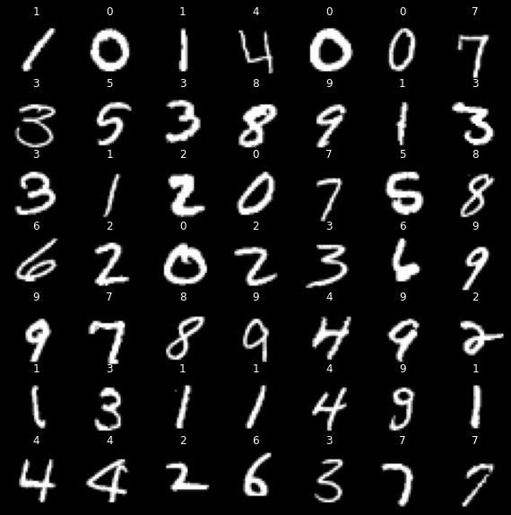

```python
plt.figure(figsize=(10, 10))
for i in range(49):
    plt.subplot(7, 7, i + 1)
    plt.imshow(X[i, :].reshape(28, 28), cmap="gray")
    plt.title(int(y[i]))
    plt.axis("off")
```

Next, we'll plot some images labelwise.

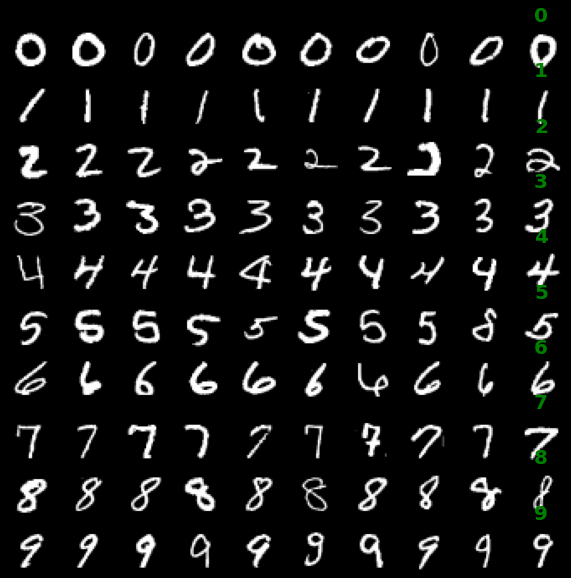

```python
fig, axes = plt.subplots(nrows=10, ncols=10, figsize=(10, 10))
for i in range(10):
    nums = train[train["label"] == i]
    X_num = nums.iloc[:, 1:].values
    y_labels = nums.iloc[:, 0].values
    for j in range(10):
        axes[i, j].imshow(X_num[j, :].reshape(28, 28), cmap="gray")
        axes[i, j].axis("off")
    axes[i, j].set_title(
        int(y_labels[i * 10 + j]),
        fontdict={"fontsize": 20, "fontweight": "bold", "color": "green"},
    )
```

We can see that some of the digits are so badly written that even a human will have problem understanding. Our model will have trouble understanding these images.

## Preparing the Dataset

These are the steps we'll follow to prepare the dataset for our model:

1. Create train test split
2. Normalize the data
3. Use `array.ravel()` to flatten the target array

```python
X_train, X_test, y_train, y_test = train_test_split(
    X, y, test_size=0.1, random_state=42
)
X_train.shape, X_test.shape, y_train.shape, y_test.shape
```

```
((37800, 784), (4200, 784), (37800, 1), (4200, 1))
```

```python
X_train = X_train / 255.0
X_test = X_test / 255.0
y_train = y_train.ravel()
y_test = y_test.ravel()
y_train.shape, y_test.shape
```

```
((37800,), (4200,))
```

# ML Models

## Making Some Functions

```python
def evaluate_model(model, on="test"):
    if on == "test":
        data = (X_test, y_test)
    else:
        data = (X_train, y_train)
    y_pred = model.predict(data[0])
    accuracy = accuracy_score(data[1], y_pred)
    print("Accuracy:", accuracy)
    print("Classification Report:")
    print(classification_report(data[1], y_pred))
    cm = confusion_matrix(data[1], y_pred)
    cmp = ConfusionMatrixDisplay(cm)
    fig, ax = plt.subplots(figsize=((10, 10)))
    cmp.plot(ax=ax, xticks_rotation="vertical")
    performance_dict = {
        "accuracy": accuracy,
        "precision": precision_score(data[1], y_pred, average="weighted"),
    }
    return performance_dict
```

```python
performance_train = {}
performance_test = {}
```

## The Base Model

The base model for ML algorithms will be the `Logistic Regression` model with default parameters.

```python
base_model = LogisticRegression(random_state=42, max_iter=1000)
base_model.fit(X_train, y_train)
```

```
Accuracy: 0.9130952380952381
Classification Report:
              precision    recall  f1-score   support

           0       0.95      0.97      0.96       408
           1       0.96      0.97      0.97       471
           2       0.90      0.90      0.90       420
           3       0.90      0.86      0.88       506
           4       0.93      0.93      0.93       397
           5       0.87      0.88      0.88       339
           6       0.94      0.93      0.94       402
           7       0.92      0.90      0.91       438
           8       0.88      0.87      0.88       403
           9       0.88      0.89      0.89       416

    accuracy                           0.91      4200
   macro avg       0.91      0.91      0.91      4200
weighted avg       0.91      0.91      0.91      4200
```

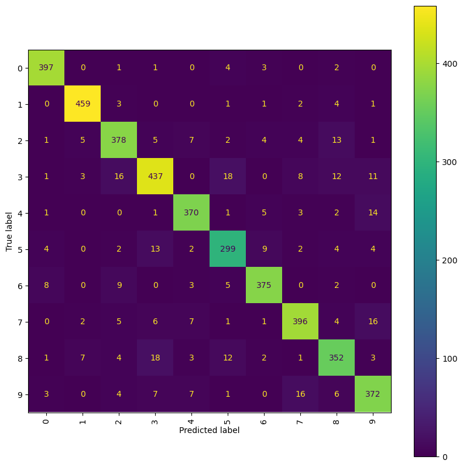

```python
performance_test["base_model"] = evaluate_model(base_model, on="test")
```

```
Accuracy: 0.9446825396825397
Classification Report:
              precision    recall  f1-score   support

           0       0.97      0.98      0.98      3724
           1       0.97      0.98      0.98      4213
           2       0.94      0.93      0.94      3757
           3       0.93      0.92      0.92      3845
           4       0.95      0.95      0.95      3675
           5       0.91      0.91      0.91      3456
           6       0.97      0.97      0.97      3735
           7       0.96      0.95      0.96      3963
           8       0.92      0.91      0.92      3660
           9       0.92      0.93      0.92      3772

    accuracy                           0.94     37800
   macro avg       0.94      0.94      0.94     37800
weighted avg       0.94      0.94      0.94     37800
```

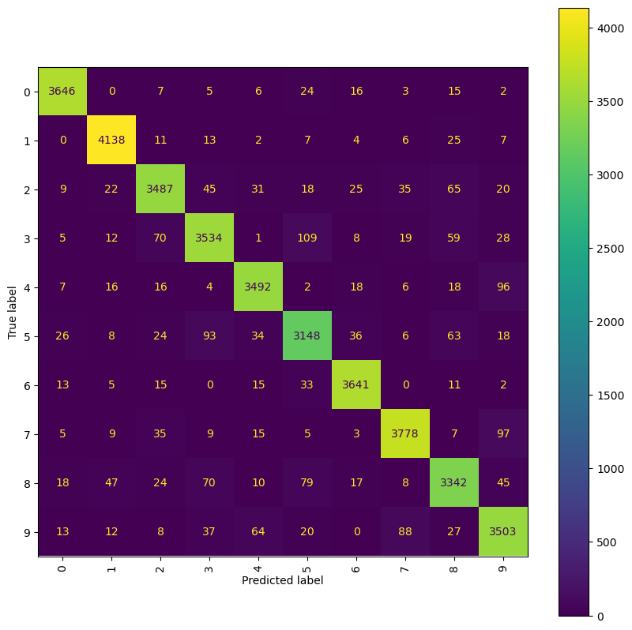

```python
performance_train["base_model"] = evaluate_model(base_model, on="train")
```

The base model gives an accuracy of about 91% on the test set.

## SVC

Next model will be the Support Vector Classifier model.

```python
svc = SVC(random_state=42)
svc.fit(X_train, y_train)
```

```
SVC(random_state=42)
```

```
Accuracy: 0.9759523809523809
Classification Report:
              precision    recall  f1-score   support

           0       0.98      0.99      0.99       408
           1       0.99      1.00      0.99       471
           2       0.98      0.97      0.98       420
           3       0.97      0.97      0.97       506
           4       0.97      0.97      0.97       397
           5       0.98      0.97      0.97       339
           6       0.99      0.99      0.99       402
           7       0.97      0.97      0.97       438
           8       0.96      0.97      0.96       403
           9       0.97      0.97      0.97       416

    accuracy                           0.98      4200
   macro avg       0.98      0.98      0.98      4200
weighted avg       0.98      0.98      0.98      4200
```

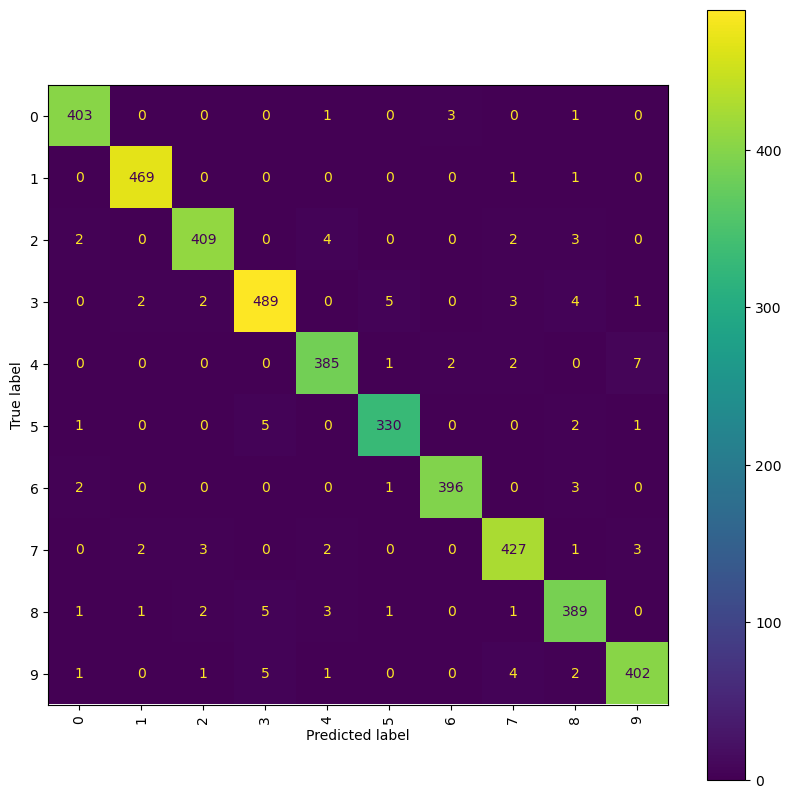

```python
performance_test["svc"] = evaluate_model(svc, on="test")
```

```
Accuracy: 0.9889417989417989
Classification Report:
              precision    recall  f1-score   support

           0       0.99      1.00      0.99      3724
           1       0.99      0.99      0.99      4213
           2       0.99      0.99      0.99      3757
           3       0.99      0.98      0.99      3845
           4       0.98      0.99      0.99      3675
           5       0.99      0.99      0.99      3456
           6       0.99      0.99      0.99      3735
           7       0.99      0.99      0.99      3963
           8       0.99      0.99      0.99      3660
           9       0.98      0.98      0.98      3772

    accuracy                           0.99     37800
   macro avg       0.99      0.99      0.99     37800
weighted avg       0.99      0.99      0.99     37800
```

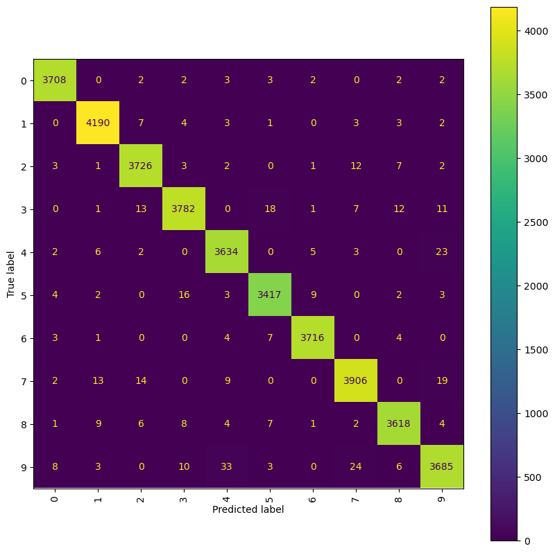

```python
performance_train["svc"] = evaluate_model(svc, on="train")
```

## KNN

```python
knnc = KNeighborsClassifier(n_neighbors=5)
knnc.fit(X_train, y_train)
```

```
KNeighborsClassifier()
```

```
Accuracy: 0.9654761904761905
Classification Report:
              precision    recall  f1-score   support

           0       0.98      1.00      0.99       408
           1       0.94      1.00      0.97       471
           2       0.98      0.96      0.97       420
           3       0.96      0.96      0.96       506
           4       0.98      0.96      0.97       397
           5       0.96      0.96      0.96       339
           6       0.97      0.99      0.98       402
           7       0.96      0.95      0.96       438
           8       0.99      0.92      0.96       403
           9       0.94      0.96      0.95       416

    accuracy                           0.97      4200
   macro avg       0.97      0.97      0.97      4200
weighted avg       0.97      0.97      0.97      4200
```

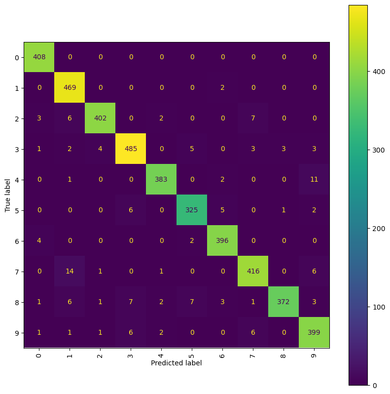

```python
performance_test["knn"] = evaluate_model(knnc, on="test")
```

```
Accuracy: 0.9782275132275132
Classification Report:
              precision    recall  f1-score   support

           0       0.98      0.99      0.99      3724
           1       0.97      1.00      0.98      4213
           2       0.99      0.97      0.98      3757
           3       0.98      0.98      0.98      3845
           4       0.98      0.97      0.98      3675
           5       0.97      0.98      0.97      3456
           6       0.98      0.99      0.99      3735
           7       0.97      0.98      0.98      3963
           8       0.99      0.95      0.97      3660
           9       0.97      0.97      0.97      3772

    accuracy                           0.98     37800
   macro avg       0.98      0.98      0.98     37800
weighted avg       0.98      0.98      0.98     37800
```

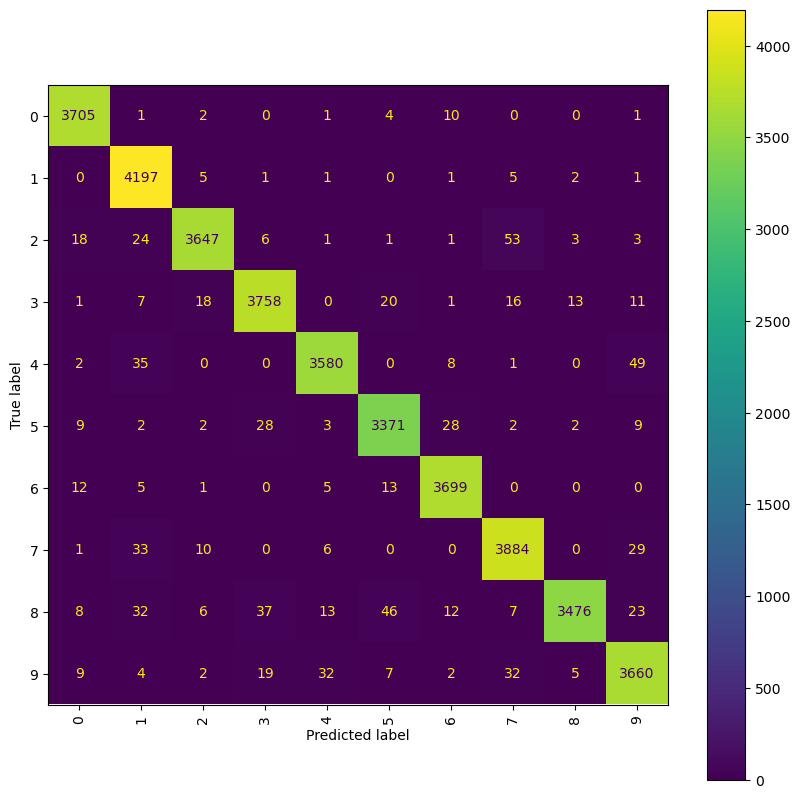

```python
performance_train["knn"] = evaluate_model(knnc, on="train")
```

97% accuracy on the test set.

## Decision Tree Classifier

```python
dtc = DecisionTreeClassifier(
    random_state=42, max_depth=10
)  # max_depth=10 else the model will overfit
dtc.fit(X_train, y_train)
```

```
DecisionTreeClassifier(max_depth=10, random_state=42)
```

```
Accuracy: 0.8442857142857143
Classification Report:
              precision    recall  f1-score   support

           0       0.94      0.92      0.93       408
           1       0.90      0.95      0.92       471
           2       0.87      0.81      0.84       420
           3       0.86      0.76      0.81       506
           4       0.82      0.84      0.83       397
           5       0.73      0.75      0.74       339
           6       0.91      0.87      0.89       402
           7       0.86      0.88      0.87       438
           8       0.75      0.78      0.77       403
           9       0.78      0.85      0.81       416

    accuracy                           0.84      4200
   macro avg       0.84      0.84      0.84      4200
weighted avg       0.85      0.84      0.84      4200
```

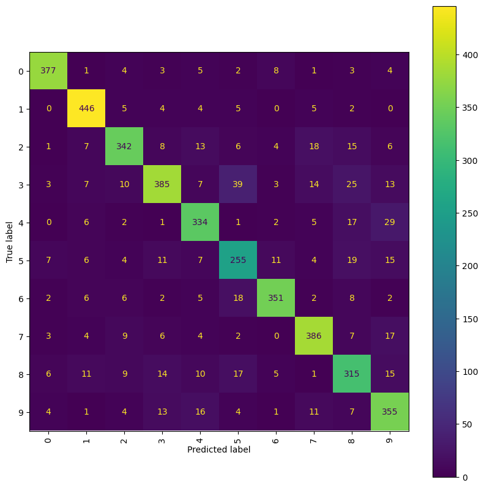

```python
performance_test["dtc"] = evaluate_model(dtc, on="test")
```

```
Accuracy: 0.9053174603174603
Classification Report:
              precision    recall  f1-score   support

           0       0.97      0.97      0.97      3724
           1       0.94      0.96      0.95      4213
           2       0.92      0.89      0.91      3757
           3       0.91      0.85      0.88      3845
           4       0.90      0.89      0.90      3675
           5       0.89      0.86      0.87      3456
           6       0.96      0.93      0.95      3735
           7       0.91      0.93      0.92      3963
           8       0.85      0.87      0.86      3660
           9       0.81      0.89      0.85      3772

    accuracy                           0.91     37800
   macro avg       0.91      0.90      0.90     37800
weighted avg       0.91      0.91      0.91     37800
```

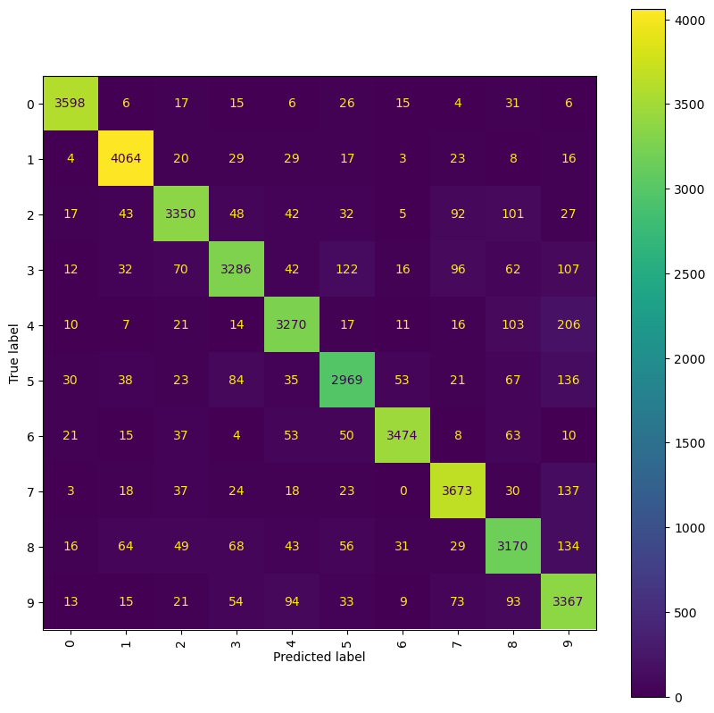

```python
performance_train["dtc"] = evaluate_model(dtc, on="train")
```

It is not performing well. Let's see if we can improve it by using Random Forest Classifier.

## Random Forest Classifier

```python
rfc = RandomForestClassifier(random_state=42, n_estimators=2500, max_depth=10)
rfc.fit(X_train, y_train)
```

```
RandomForestClassifier(max_depth=10, n_estimators=2500, random_state=42)
```

```
Accuracy: 0.9435714285714286
Classification Report:
              precision    recall  f1-score   support

           0       0.98      0.98      0.98       408
           1       0.96      0.99      0.97       471
           2       0.94      0.95      0.95       420
           3       0.94      0.90      0.92       506
           4       0.94      0.94      0.94       397
           5       0.96      0.94      0.95       339
           6       0.96      0.98      0.97       402
           7       0.95      0.92      0.93       438
           8       0.93      0.92      0.92       403
           9       0.88      0.93      0.90       416

    accuracy                           0.94      4200
   macro avg       0.94      0.94      0.94      4200
weighted avg       0.94      0.94      0.94      4200
```

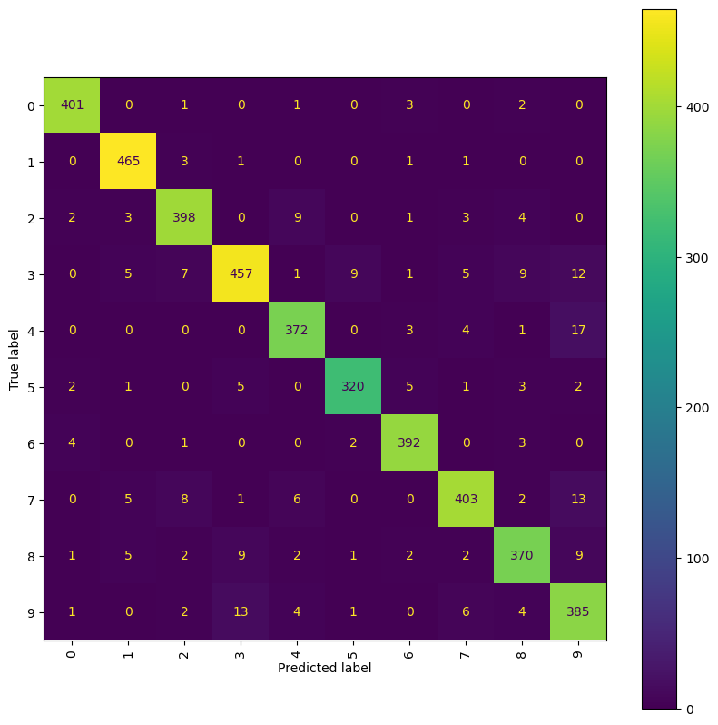

```python
performance_test["rfc"] = evaluate_model(rfc, on="test")
```

```
Accuracy: 0.9727248677248678
Classification Report:
              precision    recall  f1-score   support

           0       0.99      0.99      0.99      3724
           1       0.98      0.99      0.98      4213
           2       0.97      0.97      0.97      3757
           3       0.97      0.96      0.97      3845
           4       0.97      0.97      0.97      3675
           5       0.99      0.97      0.98      3456
           6       0.99      0.99      0.99      3735
           7       0.97      0.96      0.97      3963
           8       0.97      0.97      0.97      3660
           9       0.93      0.95      0.94      3772

    accuracy                           0.97     37800
   macro avg       0.97      0.97      0.97     37800
weighted avg       0.97      0.97      0.97     37800
```

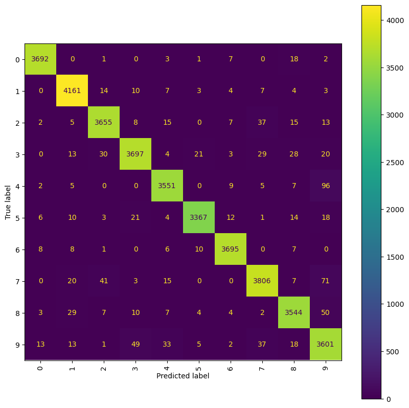

```python
performance_train["rfc"] = evaluate_model(rfc, on="train")
```

Next we'll try XGBoost.

## XGBoost

```python
xgbc = XGBClassifier(random_state=42, n_estimators=2500, max_depth=10)
xgbc.fit(X_train, y_train)
```

```
XGBClassifier(base_score=0.5, booster='gbtree', callbacks=None,
              colsample_bylevel=1, colsample_bynode=1, colsample_bytree=1,
              early_stopping_rounds=None, enable_categorical=False,
              eval_metric=None, gamma=0, gpu_id=-1, grow_policy='depthwise',
              importance_type=None, interaction_constraints='',
              learning_rate=0.300000012, max_bin=256, max_cat_to_onehot=4,
              max_delta_step=0, max_depth=10, max_leaves=0, min_child_weight=1,
              missing=nan, monotone_constraints='()', n_estimators=2500,
              n_jobs=0, num_parallel_tree=1, objective='multi:softprob',
              predictor='auto', random_state=42, reg_alpha=0, ...)
```

```
Accuracy: 0.975
Classification Report:
              precision    recall  f1-score   support

           0       0.99      0.99      0.99       408
           1       0.99      0.98      0.99       471
           2       0.97      0.97      0.97       420
           3       0.98      0.97      0.97       506
           4       0.97      0.97      0.97       397
           5       0.96      0.97      0.97       339
           6       0.98      0.99      0.98       402
           7       0.98      0.97      0.97       438
           8       0.96      0.98      0.97       403
           9       0.96      0.96      0.96       416

    accuracy                           0.97      4200
   macro avg       0.97      0.98      0.97      4200
weighted avg       0.98      0.97      0.98      4200
```

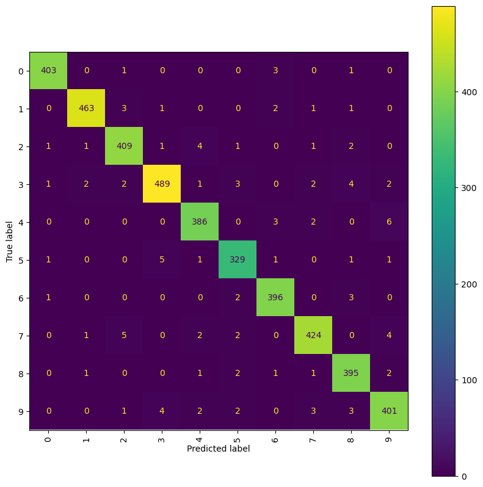

```python
performance_test["xgbc"] = evaluate_model(xgbc, on="test")
```

```
Accuracy: 1.0
Classification Report:
              precision    recall  f1-score   support

           0       1.00      1.00      1.00      3724
           1       1.00      1.00      1.00      4213
           2       1.00      1.00      1.00      3757
           3       1.00      1.00      1.00      3845
           4       1.00      1.00      1.00      3675
           5       1.00      1.00      1.00      3456
           6       1.00      1.00      1.00      3735
           7       1.00      1.00      1.00      3963
           8       1.00      1.00      1.00      3660
           9       1.00      1.00      1.00      3772

    accuracy                           1.00     37800
   macro avg       1.00      1.00      1.00     37800
weighted avg       1.00      1.00      1.00     37800
```

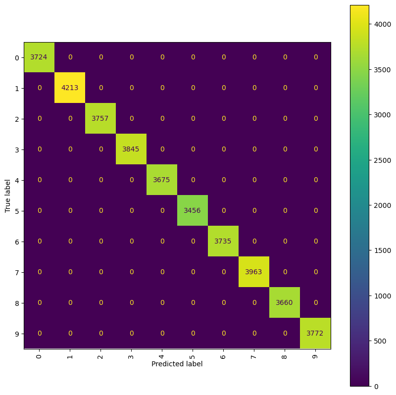

```python
performance_train["xgbc"] = evaluate_model(xgbc, on="train")
```

97.5% accuracy on test set, though the model is clearly overfitting.

Let's compare all the models.

## Compare Models

```python
performance_on_test = pd.DataFrame(performance_test).T
performance_on_test
```

|  | accuracy | precision |
| --- | --- | --- |
| base_model | 0.913095 | 0.912979 |
| svc | 0.975952 | 0.975955 |
| knn | 0.965476 | 0.965880 |
| dtc | 0.844286 | 0.845927 |
| rfc | 0.943571 | 0.943816 |
| xgbc | 0.975000 | 0.975045 |

```python
performance_on_train = pd.DataFrame(performance_train).T
performance_on_train
```

|  | accuracy | precision |
| --- | --- | --- |
| base_model | 0.944683 | 0.944606 |
| svc | 0.988942 | 0.988939 |
| knn | 0.978228 | 0.978349 |
| dtc | 0.905317 | 0.906397 |
| rfc | 0.972725 | 0.972850 |
| xgbc | 1.000000 | 1.000000 |

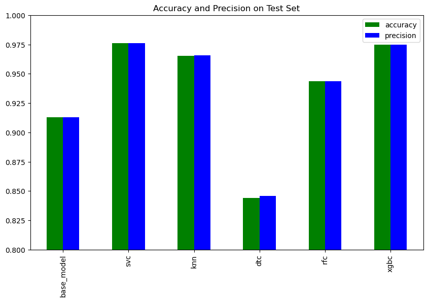

```python
performance_on_test.plot(
    kind="bar",
    figsize=(10, 6),
    title="Accuracy and Precision on Test Set",
    ylim=(0.8, 1.0),
    color=["green", "blue"],
)
```

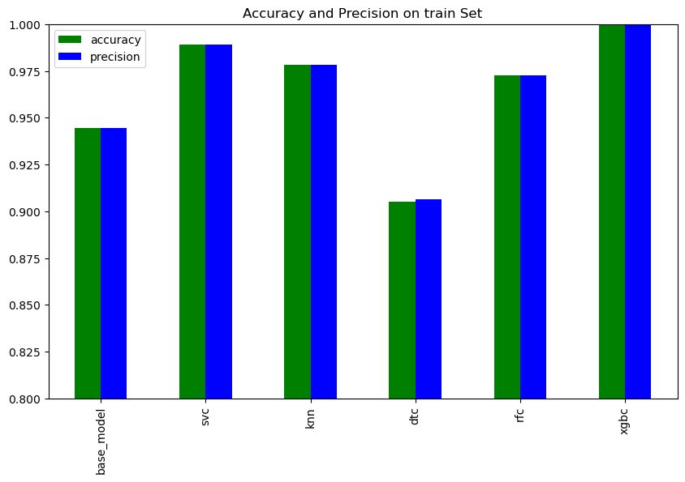

```python
performance_on_train.plot(
    kind="bar",
    figsize=(10, 6),
    title="Accuracy and Precision on train Set",
    ylim=(0.8, 1.0),
    color=["green", "blue"],
)
```